# DS 202 - Lab 3: Exploring Happiness

Due: Thursday 10/03/2019 by 10 pm

Lynna Chu

09/26/2019

```r
 HAPPY <- readRDS("HAPPY.rds")
head(HAPPY)
```

```
##           HAPPY YEAR AGE    SEX       MARITAL         DEGREE       FINRELA
## 1 NOT TOO HAPPY 1972  23 FEMALE NEVER MARRIED       BACHELOR       AVERAGE
## 2 NOT TOO HAPPY 1972  70   MALE       MARRIED LT HIGH SCHOOL ABOVE AVERAGE
## 3  PRETTY HAPPY 1972  48 FEMALE       MARRIED    HIGH SCHOOL       AVERAGE
## 4 NOT TOO HAPPY 1972  27 FEMALE       MARRIED       BACHELOR       AVERAGE
## 5  PRETTY HAPPY 1972  61 FEMALE       MARRIED    HIGH SCHOOL ABOVE AVERAGE
## 6  PRETTY HAPPY 1972  26   MALE NEVER MARRIED    HIGH SCHOOL ABOVE AVERAGE
##      HEALTH WTSSALL          PARTYID POLVIEWS
## 1      GOOD  0.4446     IND,NEAR DEM      IAP
## 2      FAIR  0.8893 NOT STR DEMOCRAT      IAP
## 3 EXCELLENT  0.8893      INDEPENDENT      IAP
## 4      GOOD  0.8893 NOT STR DEMOCRAT      IAP
## 5      GOOD  0.8893  STRONG DEMOCRAT      IAP
## 6      GOOD  0.4446     IND,NEAR DEM      IAP
```

```r
library("ggplot2")
library("dplyr")
HAPPY[HAPPY=="IAP"|HAPPY=="DK"|HAPPY=="NA"] <- NA
head(HAPPY)
```

```
##           HAPPY YEAR AGE    SEX       MARITAL         DEGREE       FINRELA
## 1 NOT TOO HAPPY 1972  23 FEMALE NEVER MARRIED       BACHELOR       AVERAGE
## 2 NOT TOO HAPPY 1972  70   MALE       MARRIED LT HIGH SCHOOL ABOVE AVERAGE
## 3  PRETTY HAPPY 1972  48 FEMALE       MARRIED    HIGH SCHOOL       AVERAGE
## 4 NOT TOO HAPPY 1972  27 FEMALE       MARRIED       BACHELOR       AVERAGE
## 5  PRETTY HAPPY 1972  61 FEMALE       MARRIED    HIGH SCHOOL ABOVE AVERAGE
## 6  PRETTY HAPPY 1972  26   MALE NEVER MARRIED    HIGH SCHOOL ABOVE AVERAGE
##      HEALTH WTSSALL          PARTYID POLVIEWS
## 1      GOOD  0.4446     IND,NEAR DEM     <NA>
## 2      FAIR  0.8893 NOT STR DEMOCRAT     <NA>
## 3 EXCELLENT  0.8893      INDEPENDENT     <NA>
## 4      GOOD  0.8893 NOT STR DEMOCRAT     <NA>
## 5      GOOD  0.8893  STRONG DEMOCRAT     <NA>
## 6      GOOD  0.4446     IND,NEAR DEM     <NA>
```

2. Check the type of the variable and cast into the right type (factor variable for categorical variables). For age, change “89 OR OLDER” to 89 and assume the variable should be numeric. (Hint: see `?as.character` and `?as.numeric`)

```r
HAPPY$AGE[HAPPY$AGE=="89 OR OLDER"] <- 89
HAPPY$AGE <- as.numeric(HAPPY$AGE)
head(HAPPY)
```

```
##           HAPPY YEAR AGE    SEX       MARITAL         DEGREE       FINRELA
## 1 NOT TOO HAPPY 1972  23 FEMALE NEVER MARRIED       BACHELOR       AVERAGE
## 2 NOT TOO HAPPY 1972  70   MALE       MARRIED LT HIGH SCHOOL ABOVE AVERAGE
## 3  PRETTY HAPPY 1972  48 FEMALE       MARRIED    HIGH SCHOOL       AVERAGE
## 4 NOT TOO HAPPY 1972  27 FEMALE       MARRIED       BACHELOR       AVERAGE
## 5  PRETTY HAPPY 1972  61 FEMALE       MARRIED    HIGH SCHOOL ABOVE AVERAGE
## 6  PRETTY HAPPY 1972  26   MALE NEVER MARRIED    HIGH SCHOOL ABOVE AVERAGE
##      HEALTH WTSSALL          PARTYID POLVIEWS
## 1      GOOD  0.4446     IND,NEAR DEM     <NA>
## 2      FAIR  0.8893 NOT STR DEMOCRAT     <NA>
## 3 EXCELLENT  0.8893      INDEPENDENT     <NA>
## 4      GOOD  0.8893 NOT STR DEMOCRAT     <NA>
## 5      GOOD  0.8893  STRONG DEMOCRAT     <NA>
## 6      GOOD  0.4446     IND,NEAR DEM     <NA>
```

```r
str(HAPPY)
```

```
## 'data.frame':    62466 obs. of  11 variables:
##  $ HAPPY   : chr  "NOT TOO HAPPY" "NOT TOO HAPPY" "PRETTY HAPPY" "NOT TOO HAPPY" ...
##  $ YEAR    : int  1972 1972 1972 1972 1972 1972 1972 1972 1972 1972 ...
##  $ AGE     : num  23 70 48 27 61 26 28 27 21 30 ...
##  $ SEX     : chr  "FEMALE" "MALE" "FEMALE" "FEMALE" ...
##  $ MARITAL : chr  "NEVER MARRIED" "MARRIED" "MARRIED" "MARRIED" ...
##  $ DEGREE  : chr  "BACHELOR" "LT HIGH SCHOOL" "HIGH SCHOOL" "BACHELOR" ...
##  $ FINRELA : chr  "AVERAGE" "ABOVE AVERAGE" "AVERAGE" "AVERAGE" ...
##  $ HEALTH  : chr  "GOOD" "FAIR" "EXCELLENT" "GOOD" ...
##  $ WTSSALL : num  0.445 0.889 0.889 0.889 0.889 ...
##  $ PARTYID : chr  "IND,NEAR DEM" "NOT STR DEMOCRAT" "INDEPENDENT" "NOT STR DEMOCRAT" ...
##  $ POLVIEWS: chr  NA NA NA NA ...
```

```r
HAPPY$HAPPY <- as.factor(HAPPY$HAPPY)
HAPPY$SEX <- as.factor(HAPPY$SEX)
HAPPY$MARITAL <- as.factor(HAPPY$MARITAL)
HAPPY$DEGREE <- as.factor(HAPPY$DEGREE)
HAPPY$FINRELA <- as.factor(HAPPY$FINRELA)
HAPPY$HEALTH <- as.factor(HAPPY$HEALTH)
HAPPY$PARTYID <- as.factor(HAPPY$PARTYID)
HAPPY$POLVIEWS <- as.factor(HAPPY$POLVIEWS)
HAPPY$YEAR <- as.numeric(HAPPY$YEAR)
#HAPPY <- HAPPY%>%
  #mutate_if(is.character, as.factor)%>%
  #mutate_if(~is.integer(.) | is.double(.), as.numeric)
head(HAPPY)
```

```
##           HAPPY YEAR AGE    SEX       MARITAL         DEGREE       FINRELA
## 1 NOT TOO HAPPY 1972  23 FEMALE NEVER MARRIED       BACHELOR       AVERAGE
## 2 NOT TOO HAPPY 1972  70   MALE       MARRIED LT HIGH SCHOOL ABOVE AVERAGE
## 3  PRETTY HAPPY 1972  48 FEMALE       MARRIED    HIGH SCHOOL       AVERAGE
## 4 NOT TOO HAPPY 1972  27 FEMALE       MARRIED       BACHELOR       AVERAGE
## 5  PRETTY HAPPY 1972  61 FEMALE       MARRIED    HIGH SCHOOL ABOVE AVERAGE
## 6  PRETTY HAPPY 1972  26   MALE NEVER MARRIED    HIGH SCHOOL ABOVE AVERAGE
##      HEALTH WTSSALL          PARTYID POLVIEWS
## 1      GOOD  0.4446     IND,NEAR DEM     <NA>
## 2      FAIR  0.8893 NOT STR DEMOCRAT     <NA>
## 3 EXCELLENT  0.8893      INDEPENDENT     <NA>
## 4      GOOD  0.8893 NOT STR DEMOCRAT     <NA>
## 5      GOOD  0.8893  STRONG DEMOCRAT     <NA>
## 6      GOOD  0.4446     IND,NEAR DEM     <NA>
```

```r
str(HAPPY)
```

```
## 'data.frame':    62466 obs. of  11 variables:
##  $ HAPPY   : Factor w/ 3 levels "NOT TOO HAPPY",..: 1 1 2 1 2 2 1 1 2 2 ...
##  $ YEAR    : num  1972 1972 1972 1972 1972 ...
##  $ AGE     : num  23 70 48 27 61 26 28 27 21 30 ...
##  $ SEX     : Factor w/ 2 levels "FEMALE","MALE": 1 2 1 1 1 2 2 2 1 1 ...
##  $ MARITAL : Factor w/ 5 levels "DIVORCED","MARRIED",..: 3 2 2 2 2 3 1 3 3 2 ...
##  $ DEGREE  : Factor w/ 5 levels "BACHELOR","GRADUATE",..: 1 5 3 1 3 3 3 1 3 3 ...
##  $ FINRELA : Factor w/ 5 levels "ABOVE AVERAGE",..: 2 1 2 2 1 1 1 2 2 3 ...
##  $ HEALTH  : Factor w/ 4 levels "EXCELLENT","FAIR",..: 3 2 1 3 3 3 1 3 1 2 ...
##  $ WTSSALL : num  0.445 0.889 0.889 0.889 0.889 ...
##  $ PARTYID : Factor w/ 8 levels "IND,NEAR DEM",..: 1 4 3 4 7 1 1 1 7 7 ...
##  $ POLVIEWS: Factor w/ 7 levels "CONSERVATIVE",..: NA NA NA NA NA NA NA NA NA NA ...
```

3. Bring all levels of factors into a sensible order. For marital you could e.g. order the levels according to average age.

```r
HAPPY <- HAPPY %>%
  mutate(HAPPY = factor(HAPPY, levels=c("NOT TOO HAPPY", "PRETTY HAPPY", "VERY HAPPY"))) %>%
  mutate(DEGREE = factor(DEGREE, levels=c("LT HIGH SCHOOL", "HIGH SCHOOL", "JUNIOR COLLEGE", "BACHELOR", "GRADUATE" ))) %>%
  mutate(SEX = factor(SEX, levels=c("FEMALE", "MALE"))) %>%
  mutate(FINRELA = factor(FINRELA, levels=c("FAR BELOW AVERAGE", "BELOW AVERAGE", "AVERAGE", "ABOVE AVERAGE", "FAR ABOVE AVERAGE"))) %>%
  mutate(HEALTH = factor(HEALTH, levels=c("POOR", "FAIR", "GOOD", "EXCELLENT"))) %>%
  mutate(PARTYID = factor(PARTYID, levels=c("STRONG REPUBLICAN", "NOT STR REPUBLICAN", "IND,NEAR REP", "INDEPENDENT", "IND,NEAR DEM", "NOT STR DEMOCRAT", "STRONG DEMOCRAT", "OTHER PARTY"))) %>%
  mutate(POLVIEWS = factor(POLVIEWS, levels=c("EXTRMLY CONSERVATIVE", "SLGHTLY CONSERVATIVE", "CONSERVATIVE", "MODERATE", "LIBERAL", "SLIGHTLY LIBERAL", "EXTREMELY LIBERAL")))
#MARITAL column has no obvious order
#sort by average age of aggregated/grouped MARITAL value
subset_marital<- aggregate(AGE ~ MARITAL, data = HAPPY, mean) %>%
  arrange(AGE)
HAPPY <- mutate(HAPPY, MARITAL = factor(MARITAL, as.vector(subset_marital$MARITAL)))
lapply(HAPPY, levels)
```

```
## $HAPPY
## [1] "NOT TOO HAPPY" "PRETTY HAPPY"  "VERY HAPPY"
##
## $YEAR
## NULL
##
## $AGE
## NULL
##
## $SEX
## [1] "FEMALE" "MALE"
##
## $MARITAL
## [1] "NEVER MARRIED" "SEPARATED"     "MARRIED"       "DIVORCED"
## [5] "WIDOWED"
##
## $DEGREE
## [1] "LT HIGH SCHOOL" "HIGH SCHOOL"    "JUNIOR COLLEGE" "BACHELOR"
## [5] "GRADUATE"
##
## $FINRELA
## [1] "FAR BELOW AVERAGE" "BELOW AVERAGE"     "AVERAGE"
## [4] "ABOVE AVERAGE"     "FAR ABOVE AVERAGE"
##
## $HEALTH
## [1] "POOR"      "FAIR"      "GOOD"      "EXCELLENT"
##
## $WTSSALL
## NULL
##
## $PARTYID
## [1] "STRONG REPUBLICAN"  "NOT STR REPUBLICAN" "IND,NEAR REP"
## [4] "INDEPENDENT"        "IND,NEAR DEM"       "NOT STR DEMOCRAT"
## [7] "STRONG DEMOCRAT"    "OTHER PARTY"
##
## $POLVIEWS
## [1] "EXTRMLY CONSERVATIVE" "SLGHTLY CONSERVATIVE" "CONSERVATIVE"
## [4] "MODERATE"             "LIBERAL"              "SLIGHTLY LIBERAL"
## [7] "EXTREMELY LIBERAL"
```

Use `ggplot2` to create the plots. Your exploration should make use all elements of the grammar of graphics: mappings (`color`, `fill`, and `size` at least), different `geom`s (4 at least), scales, coordinates (eg `coord_flip`), facet, and theme (eg setting axis labels and title). **The final plot doesn’t need to include all these elements, but they should be part of your exploration**. For each investigation, create an appropriate visualization and write a paragraph to describe it.

1. Investigate the distributions of 2 different variables.
2. Investigate the relationship between happiness and three other variables in the data.
3. What do you learn from the data set? Write one or two paragraphs to describe.

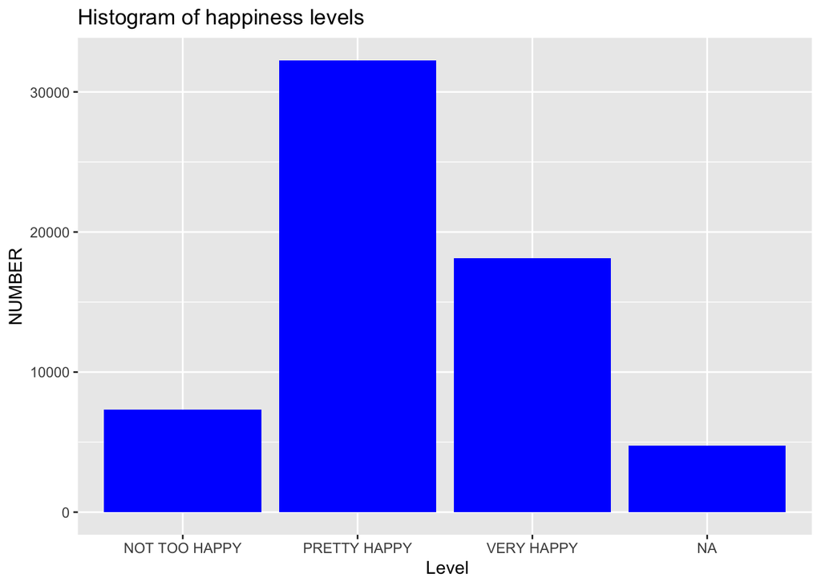

```r
plot1 <- ggplot(data=HAPPY,aes(HAPPY))+geom_histogram(fill="blue",stat="count")+labs(x=" Level",y="NUMBER",title="Histogram of happiness levels")
print(plot1)
```

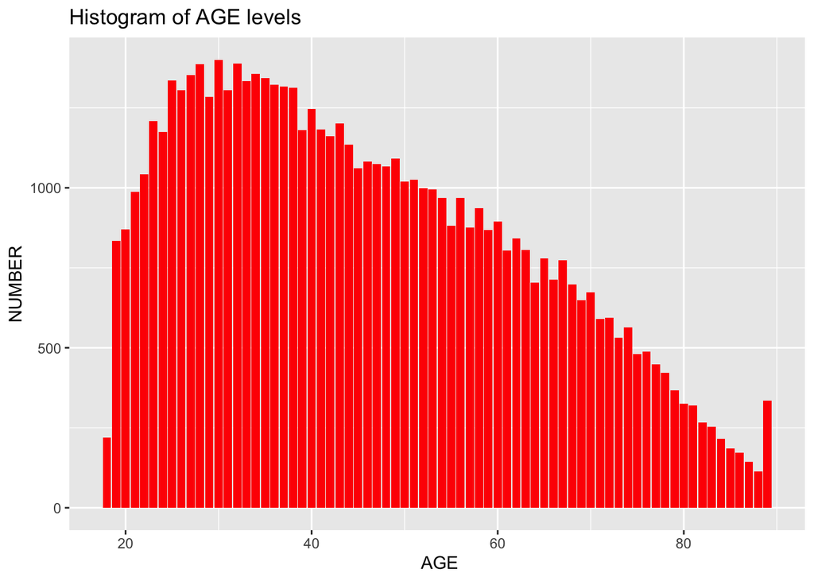

```r
plot1 <- ggplot(data=HAPPY,aes(AGE))+geom_histogram(fill="RED",stat="count")+labs(x=" AGE",y="NUMBER",title="Histogram of AGE levels")
print(plot1)
```

2. Investigate the relationship between happiness and three other variables in the data.

```r
subset_happy_marriage <- HAPPY %>% select(HAPPY, MARITAL)
subset_happy_marriage
```

[output not shown]

[output cut: 49986 more lines]

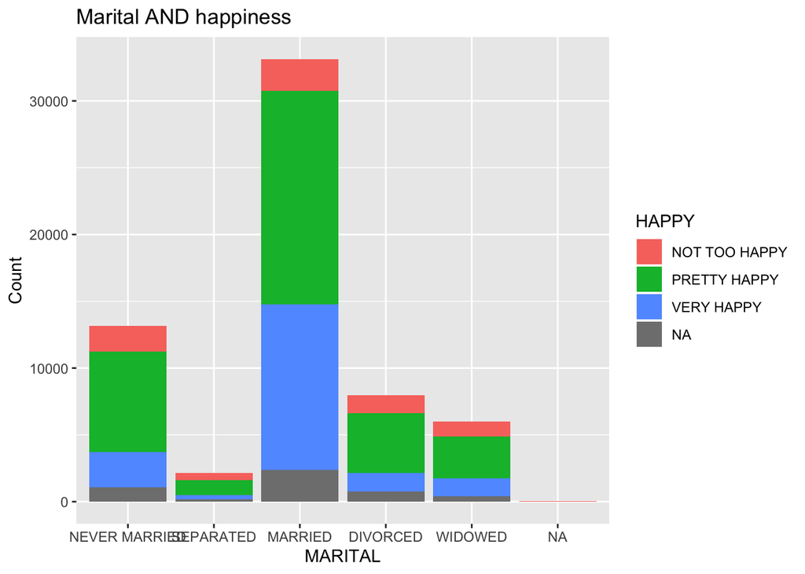

```r
plot1b <- ggplot(subset_happy_marriage, aes(x=MARITAL, fill=HAPPY)) +
  geom_histogram(stat="count") + ylab("Count")+ggtitle("Marital AND happiness")
print(plot1b)
```

```r
subset_happy_age <- HAPPY %>% select(HAPPY, AGE)
```

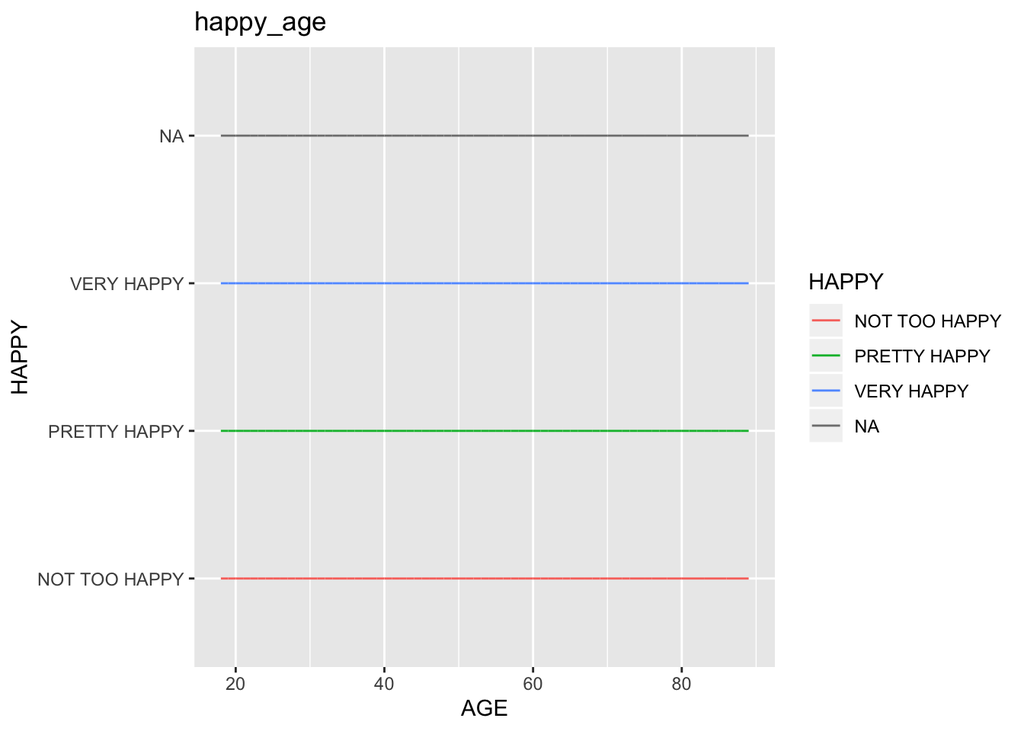

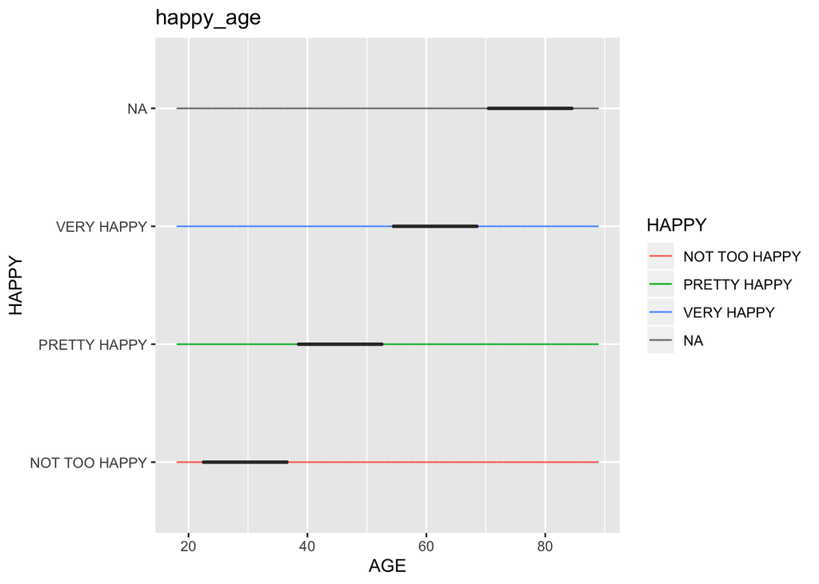

```r
plot2 <- ggplot(subset_happy_age, aes(x=AGE, y=HAPPY),shape=cut) +
  geom_line( aes(color=HAPPY) ) +ggtitle("happy_age")
print(plot2)+ geom_boxplot()
```

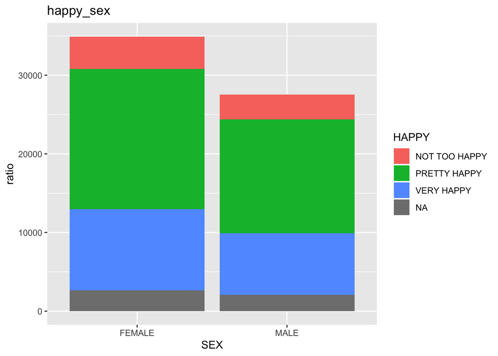

```r
subset_happy_sex <- HAPPY %>% select(HAPPY, SEX)
plot3 <- ggplot(subset_happy_sex, aes(x=SEX, fill=HAPPY)) +
  geom_bar() + ylab("ratio")+ ggtitle("happy_sex")
print(plot3)
```

3. What do you learn from the data set? Write one or two paragraphs to describe.